# NYCFlights: Arrival Delay Logistic Model

Shibani Misra

10/24/2016

# Logistic and Inverse Logistic Transformation

- Write an R function for the logistic function. The function should accept a `numeric` vector with values `[-Inf,Inf]` and produce a numeric vector in the the range `[0,1]`.

```r
getp <- function(y) {
  exp(y)/(1+exp(y))
}
```

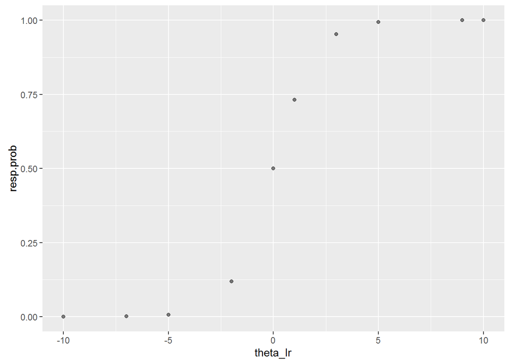

```r
theta_lr <- sample(-10:10, 10, replace=FALSE)

resp.prob <-  as.data.frame(unlist(lapply(theta_lr, getp)))
df <- cbind(as.data.frame(theta_lr),resp.prob)

ggplot(df, aes(x = theta_lr, y = resp.prob)) +
  geom_point(alpha = 0.5)
```

- Write a R function for the inverse logistic function. The function should accept a `numeric` vector with values `[0,1]` and prodcuce a numeric vector in the range `[-Inf,Inf]`

```r
inv_log <- function(p){
  log(p/(1-p))
}
```

- Plot the Inverse Logistic function from `[0,1]`

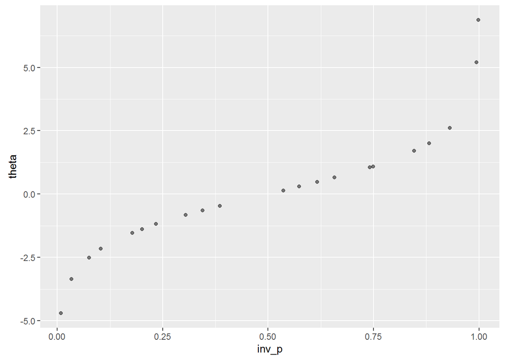

```r
inv_p <- as.data.frame(runif(21))
theta <- as.data.frame(unlist(lapply(inv_p, inv_log)))
df2 <- cbind(inv_p,theta)
ggplot(df2, aes(x = inv_p, y = theta)) + geom_point(alpha = 0.5)
```

**Hint:** For plotting curves see `?graphics::curve` or `?ggplot2::stat_function`

# NYCFlights Model

Using the rectangular data that you created from assignment and following the *Predicting Medical Expenses* example from the text (*MLwR*), create a model for arr_delay >= 15 minutes. Follow *MLwR* structure for building a model. Describe/Explain each of the steps and show all work in codeblocks below.

KNIT YOUR DOCUMENT AS *HTML* AND SUBMIT IT AND THE `Rmd` file.

## Step 1: Collect Data

```r
options(stringsAsFactors = FALSE)

flights.mod <- read.csv("C:/Users/smisra/tmp/CSX460/03-linear-regression/flightDataWithOtherInfo.csv")
flights.mod <- flights.mod %>%
  filter(is.na(arr_delay)== FALSE)

flights.additionalcols <- flights.mod  %>%
mutate(season = ifelse(month.x %in% c(12,1,2), "Winter", ifelse(month.x %in% c(3,4,5), "Spring", ifelse(month.x %in% c(6,7,8), "Summer", "Fall"))), headwind = cos(wind_dir) * wind_speed,
       wday = weekdays(as.Date(flight_date))) %>%
mutate(season = as.factor(season), wday = as.factor(wday), headwind = abs(headwind))
trainIndex <- createDataPartition(flights.additionalcols$arr_delay, p = .8,
                                  list = FALSE,
                                  times = 1)

flightTrain <- flights.additionalcols[ trainIndex,]
flightTest  <- flights.additionalcols[-trainIndex,]
```

## Step 2: Explore and Prep The Data

```r
flightTrain <- flightTrain %>%
  mutate(arr_delay_cat = ifelse(arr_delay >=15, 1,0))
flightTest <- flightTest %>%
  mutate(arr_delay_cat = ifelse(arr_delay >=15, 1, 0))
```

## Step 3: Train The Model

```r
form <- arr_delay_cat ~ dep_delay + wind_gust + season + wday + precip
flights.glm.model <- glm(form, data = flightTrain, family = binomial())
```

## Step 4: Evaluate Performance

```r
summary(flights.glm.model)
```

```
##
## Call:
## glm(formula = form, family = binomial(), data = flightTrain)
##
## Deviance Residuals:
##     Min       1Q   Median       3Q      Max
## -3.3891  -0.4271  -0.3369  -0.2025   3.7559
##
## Coefficients:
##                Estimate Std. Error z value Pr(>|z|)
## (Intercept)   -2.653156   0.026587 -99.791  < 2e-16 ***
## dep_delay      0.107667   0.000503 214.064  < 2e-16 ***
## wind_gust      0.007884   0.001081   7.290 3.11e-13 ***
## seasonSpring   0.210543   0.020348  10.347  < 2e-16 ***
## seasonSummer   0.286916   0.020086  14.284  < 2e-16 ***
## seasonWinter   0.459555   0.019963  23.020  < 2e-16 ***
## wdayMonday     0.049080   0.025015   1.962 0.049759 *
## wdaySaturday  -0.323295   0.028171 -11.476  < 2e-16 ***
## wdaySunday    -0.098405   0.025750  -3.821 0.000133 ***
## wdayThursday   0.139098   0.024582   5.659 1.53e-08 ***
## wdayTuesday    0.092222   0.025000   3.689 0.000225 ***
## wdayWednesday  0.163424   0.024724   6.610 3.85e-11 ***
## precip         5.539249   0.333420  16.613  < 2e-16 ***
## ---
## Signif. codes:  0 '***' 0.001 '**' 0.01 '*' 0.05 '.' 0.1 ' ' 1
##
## (Dispersion parameter for binomial family taken to be 1)
##
##     Null deviance: 289319  on 260186  degrees of freedom
## Residual deviance: 147961  on 260174  degrees of freedom
##   (1692 observations deleted due to missingness)
## AIC: 147987
##
## Number of Fisher Scoring iterations: 7
```

```r
arr_delay_cat_pred <- as.data.frame(predict(flights.glm.model, type = "response"))
colnames(arr_delay_cat_pred) <- c("predicted_arr_delay_prob")
threshold = 0.5
arr_delay_cat_pred <- arr_delay_cat_pred %>%
  mutate(predicted_arr_delay_01 =  ifelse(predicted_arr_delay_prob > 0.5, 1, 0))
flightTrain <- flightTrain %>%
  filter(is.na(arr_delay) == FALSE)
```

## Step 5: Improve Performance

# Question:

Is this a good model? (Write your answer here.)

Couldn’t check for model performance because for some reason the length of the predicted values vector is not matching the actual response value vector.

# PART B:

Your model should be good at explaining tardiness. Now, assume that your job is to predict arrival delays a month in advance. You can no longer use all the features in your model. Retrain your model using only features that will be *known* only a month in advance of the departure time. Show all steps as above.

```r
form2 <- arr_delay_cat ~ season + wday + origin + carrier
flights.glm.model2 <- glm(form2, data = flightTrain, family = binomial())
summary(flights.glm.model2)
```

```
##
## Call:
## glm(formula = form2, family = binomial(), data = flightTrain)
##
## Deviance Residuals:
##     Min       1Q   Median       3Q      Max
## -1.1553  -0.7892  -0.6712  -0.4165   2.4191
##
## Coefficients:
##               Estimate Std. Error z value Pr(>|z|)
## (Intercept)   -1.40745    0.02786 -50.518  < 2e-16 ***
## seasonSpring   0.53188    0.01389  38.279  < 2e-16 ***
## seasonSummer   0.77716    0.01360  57.151  < 2e-16 ***
## seasonWinter   0.64267    0.01399  45.947  < 2e-16 ***
## wdayMonday    -0.03313    0.01643  -2.016 0.043846 *
## wdaySaturday  -0.56118    0.01923 -29.178  < 2e-16 ***
## wdaySunday    -0.24141    0.01725 -13.993  < 2e-16 ***
## wdayThursday   0.08944    0.01631   5.484 4.16e-08 ***
## wdayTuesday   -0.17471    0.01676 -10.426  < 2e-16 ***
## wdayWednesday -0.11838    0.01667  -7.103 1.22e-12 ***
## originJFK     -0.03292    0.01552  -2.121 0.033945 *
## originLGA     -0.04778    0.01421  -3.362 0.000775 ***
## carrierAA     -0.38886    0.02587 -15.033  < 2e-16 ***
## carrierAS     -0.75081    0.12039  -6.237 4.47e-10 ***
## carrierB6      0.06095    0.02254   2.704 0.006852 **
## carrierDL     -0.39968    0.02423 -16.498  < 2e-16 ***
## carrierEV      0.30493    0.02535  12.027  < 2e-16 ***
## carrierF9      0.53632    0.09298   5.768 8.02e-09 ***
## carrierFL      0.39145    0.04827   8.110 5.06e-16 ***
## carrierHA     -0.86935    0.18326  -4.744 2.10e-06 ***
## carrierMQ      0.11209    0.02631   4.260 2.04e-05 ***
## carrierOO      0.41769    0.45225   0.924 0.355698
## carrierUA     -0.20183    0.02530  -7.976 1.51e-15 ***
## carrierUS     -0.41139    0.02962 -13.888  < 2e-16 ***
## carrierVX     -0.44478    0.04534  -9.811  < 2e-16 ***
## carrierWN     -0.01002    0.03239  -0.309 0.757093
## carrierYV      0.30944    0.10690   2.895 0.003795 **
## ---
## Signif. codes:  0 '***' 0.001 '**' 0.01 '*' 0.05 '.' 0.1 ' ' 1
##
## (Dispersion parameter for binomial family taken to be 1)
##
##     Null deviance: 291434  on 261878  degrees of freedom
## Residual deviance: 282920  on 261852  degrees of freedom
## AIC: 282974
##
## Number of Fisher Scoring iterations: 4
```